# Monitoring Manager Assignment

Tasbiul

18 August 2026

# Scope and method

I utilized R (R Markdown, latex functions, pdf and html exports) to develop this answer sheet so the work can be checked, repeated, and updated if the source files changes. I choose R to depict my capability in producing dynamic and automated qualitative+quantitative reports in cases of recurring reporting. For better visibility the PDF outputs will not include the underlying codes; however, in the attached, (.HTML); I am providing the Code+Output for detailed inspection. Also, I have added detailed comments inline with the code and statistical calculations (where necessary) for improved understanding. I have put all the data operations (cleaning/ wrangling) in the section 2 along with some summary table for my and readers understanding of the data. Therefore section 2 can be considered as optional to review. I intentionally put this section for review by whomever is interested in understanding the whole process of my analysis approach.

The main question answering spans from section 3-6. I have included the questions in reddish-pink boxes above each answer sections (pdf document).

## Why I chose R

**Reproducible reports:** Once format is developed, I don’t need to worry about any formatting issues unlike MS Word to generate publishable quality report structure. **Error management:** Reduced scope of tabulation error.

**Data sources:**

- `Average_sessions_details.xlsx`
- `CCP_Monitoring_Data.xlsx`

**Assignment instructions:**

- `Monitoring Manager Assignment.pdf`

# Data problems and fixes

**In data processing** I checked, cleaned, and reconciled the two provided data sources before answering tasks. The original values were kept unless a spelling, punctuation, whitespace, or header correction was required.

**Table 1: Problems found and how they were handled**

| issue | Frequency | Improvements |
| --- | --- | --- |
| Misspelled header | 1 | Fixed the spelling in the column name; values stayed the same |
| Location spelling/punctuation variants | 28 | Made spelling, spacing, and punctuation consistent |
| City-vs-district geography | 4 | Kept the city rows; used parent districts only when comparing files |
| Facility-name formatting/location variants | 36 | Fixed spacing, commas, and clear location spelling errors |
| Facility categories vs brief | 9 | Kept all 9 types and noted that the brief says 8 |
| District facility-count disagreement | 59 | Kept both counts and marked the districts that need checking |
| Unspecified averaging window | 658 | Used the given monthly averages and clearly stated the limitation |
| Unusual monitoring values | 4 | Kept the values and marked them for checking |
| Unusual historical values | 20 | Kept the values and marked them for checking |

After a successful data wrangling and processing, the 13 basic format and validation checks were conducted and found no errors. The following are the list of validation checks and afterwards I have provided methods of data checks (through data joins) and the list of changes I have made.

**Table 2: Data validation checks**

| check | failures |
| --- | --- |
| Numeric conversion failures | 0 |
| Missing required values | 0 |
| Exact duplicate rows | 0 |
| Normalized-key duplicates | 0 |
| Non-finite values | 0 |
| Negative values | 0 |
| Fractional counts | 0 |
| Invalid percentages | 0 |
| Monitoring formula mismatches | 0 |
| Historical formula mismatches | 0 |
| Future activation years | 0 |
| Division conflicts | 0 |
| Unmatched geographies | 0 |

The monitoring file has 68 reporting areas. For the cross-file comparison only (in the joined dataset). I have summarized the historical data (Average_sessions_details.xlsx) up to district level to match the format of monitoring data (CCP_Monitoring_Data.xlsx) before comparing. I grouped 4 city rows (from monitoring data) with their respective parent districts, resulting in 64 unique comparable districts as expected. Both files cover 658 facilities in total, but 59 of those districts have different facility counts. I kept both counts because the files do not show which one is the latest data (need to review the data and identify the correct facility information). In doing all the these data wrangling I performed the following sets of corrections:

**Table 3: Location names that were fixed**

*Note*: I developed custom functions (see the code in html version) to operate the validation checks and improvements.

| source | field | original | corrected |
| --- | --- | --- | --- |
| Monitoring | Location | Chattogram / Cox’s Bazar | Chattogram / Cox’s Bazar |
| Monitoring | Location | Dhaka / Narshingdi | Dhaka / Narsingdi |
| Historical | Location | Barishal / Jhalakathi | Barishal / Jhalokathi |
| Historical | Location | Rangpur / Thakurgaong | Rangpur / Thakurgaon |
| Historical | Location | Rajshahi / Bogra | Rajshahi / Bogura |
| Historical | Location | Chattogram / Laxmipur | Chattogram / Lakshmipur |
| Historical | Location | Barisal / Pirojpur | Barishal / Pirojpur |
| Historical | Location | Barisal / Jhalokathi | Barishal / Jhalokathi |
| Historical | Location | Barisal / Barguna | Barishal / Barguna |
| Historical | Location | Barisal / Patuakhali | Barishal / Patuakhali |
| Historical | Location | Dhaka / Sariatpur | Dhaka / Shariatpur |
| Historical | Location | Barisal / Bhola | Barishal / Bhola |

**Table 4: Examples of facility names that were fixed**

| row | original | corrected |
| --- | --- | --- |
| 56 | Adhunik District Sadar Hospital, Khagrachari | Adhunik District Sadar Hospital, Khagrachhari |
| 130 | Belabo Upazila Health Complex, Narshingdi | Belabo Upazila Health Complex, Narsingdi |
| 131 | Monohardi Upazila Health Complex, Narshingdi | Monohardi Upazila Health Complex, Narsingdi |
| 132 | Palash Upazila Health Complex, Narshingdi | Palash Upazila Health Complex, Narsingdi |
| 133 | Raipura Upazila Health Complex, Narshingdi | Raipura Upazila Health Complex, Narsingdi |
| 134 | Shibpur Upazila Health Complex, Narshingdi | Shibpur Upazila Health Complex, Narsingdi |
| 153 | Ghatail Upazila Health Complex,Tangail | Ghatail Upazila Health Complex, Tangail |
| 154 | Kalihati Upazila Health Complex,Tangail | Kalihati Upazila Health Complex, Tangail |
| 155 | Nagarpur Upazila Health Complex,,Tangail | Nagarpur Upazila Health Complex, Tangail |
| 156 | Mirzapur Upazila Health Complex,Tangail | Mirzapur Upazila Health Complex, Tangail |

In the historical data file there are 36 facility-name fixes in total. They cover line breaks, apostrophes, commas, spacing, and clear district spelling errors. I did not change other words because there is no official facility list in the files.

**Table 5: Values that should be reverified**

| source | row | location | indicator | value |
| --- | --- | --- | --- | --- |
| Monitoring | 17 | Chattogram / Noakhali | Sessions vs target % | 44.2 |
| Monitoring | 27 | Dhaka / Narayanganj | Sessions vs target % | 39.6 |
| Monitoring | 54 | Rangpur / Dinajpur | Sessions vs target % | 38.0 |
| Monitoring | 19 | Dhaka / Dhaka | Sessions vs target % | 35.7 |
| Historical | 222 | Barishal / Patuakhali | Average monthly sessions | 47.8 |
| Historical | 404 | Khulna / Kushtia | Average monthly sessions | 39.3 |
| Historical | 555 | Rajshahi / Bogura | Average monthly sessions | 34.0 |
| Historical | 142 | Dhaka / Munshiganj | Average monthly sessions | 33.1 |
| Historical | 107 | Mymensingh / Sherpur | Average monthly sessions | 31.2 |
| Historical | 379 | Chattogram / Brahmanbaria | Average monthly sessions | 28.0 |
| Historical | 41 | Mymensingh / Mymensingh | Average monthly sessions | 27.6 |
| Historical | 235 | Rangpur / Dinajpur | Average monthly sessions | 27.4 |

The full review table contains 24 flags. Here For both datasets, I have compared each value only with similar records in that groups. For example, In the monitoring dataset, districts were compared with other districts in the same division. Similarly, In the historical dataset, facilities were compared with other facilities of the same type. Now, a value is flagged when it was far outside the usual range of its comparison group (in statistical terms I have considered the calculation of three times the interquartile range (IQR), separately for each comparison group). This was a empirical check, designed to identify only very unusual results. So in simple terms, flags do not mean the values are incorrect; they indicate records that should be verified against source documents.

Four monitoring districts have unusually low sessions-versus-target results compared with other districts in their divisions: Dhaka (35.7%), Narayanganj (39.6%), Dinajpur (38.0%), and Noakhali (44.2%). The other 20 flags are historical facilities with unusually high average monthly sessions compared with facilities of the same type: 14 Upazila Health Complexes, 3 District Hospitals, 2 Medical College Hospitals, and 1 Specialized Hospital. No unusual values were found for QA coverage, sessions per facility, or participants per session. These are statistical review signals, not confirmed errors; high-volume facilities or genuine delivery problems could explain them, so I retained every value and marked it for verification.

**Table 6: Estimated number of months behind the historical averages**

| active_since | facilities | minimum_implied_months | median_implied_months | maximum_implied_months |
| --- | --- | --- | --- | --- |
| 2022 | 20 | 22 | 31.5 | 41 |
| 2023 | 37 | 8 | 22.0 | 30 |
| 2024 | 338 | 2 | 12.0 | 19 |
| 2025 | 170 | 1 | 5.0 | 9 |
| 2026 | 93 | 1 | 4.0 | 7 |

Here, The implied month is calculated as: Total sessions ÷ Average monthly sessions = implied number of months $\approx$ Total participants ÷ monthly participants. The session and participant averages use the same number of months for every facility, which is a good sign. However, facilities with the same start year often have very different month counts (depicted in minimum, median and maximum active month counts). Since the file provides data summarized at a single time point, I used the monthly averages as given. More detailed longitudinal data (longer timeline data) would provide more insights to be uncovered.

# A. Quantitative analysis and management recommendations

## Task A1 — Division roll-up and ranking

**Task A1:** Using `CCP_Monitoring_Data`, roll up the district-level figures to division level and calculate a division-level “% Sessions vs Target” (weighted by session volume, not a simple average of the district percentages). Rank the 8 divisions from strongest to weakest.

### Answer

**Calculation method**

Following the given instruction, I have considered aggregating all sessions to be used as weights. However, I have used statistical function to calculate the weighted average to preserve the weighted session vs target percent scale (0-100) [Click me](https://www.geeksforgeeks.org/maths/weighted-average-formula/) for more details on weighted average calculation.

So in order to achieve the weighted average, **step 1:** for district (d), total quarterly sessions are the sum of the six condition-area session fields:

$$S_d = ANC_d + PNC_d + SCANU_d + GM_d + GS_d + NCD_d$$

Now, **step 2:** for division (v), the session volume weighted, session vs target percentage is:

$$Weighted\ Session\ vs\ Target\ \%_v =
\frac{\sum_{d \in v}\left(session\ vs\ Target\ \%_d \times S_d\right)}
{\sum_{d \in v} S_d}$$

The calculation keeps `session vs Target %` on its initial 0–100 scale, but this percentage took account of the session counts and summerized at division level (as requried in the question). Then, divisions are ranked in descending order of this weighted result `Weighted Session vs Target %`;

**Table 7: Division ranking from strongest to weakest**

**Note**: to keep the column name short I have renamed `Weighted Session vs Target %` –> `Weighted Target %`

| Rank | Division | Facilities | Sessions | Participants | Weighted target % | Weighted QA % |
| --- | --- | --- | --- | --- | --- | --- |
| 1 | Mymensingh | 30 | 500 | 1851 | 90.9 | 73.9 |
| 2 | Barishal | 68 | 1624 | 5553 | 90.9 | 63.1 |
| 3 | Chattogram | 128 | 2378 | 8490 | 87.6 | 67.4 |
| 4 | Rajshahi | 88 | 1784 | 6360 | 87.2 | 76.1 |
| 5 | Sylhet | 36 | 628 | 1973 | 87.1 | 70.5 |
| 6 | Khulna | 96 | 1938 | 6927 | 86.3 | 74.1 |
| 7 | Rangpur | 67 | 1328 | 4537 | 84.5 | 73.8 |
| 8 | Dhaka | 145 | 2428 | 8664 | 80.5 | 73.8 |

**Table Interpretation**

As the target ranking uses session volume as the weights, Therefore a district running many sessions has more influence than one running only a few. Mymensingh and Barishal both round to 90.9%; Mymensingh is only slightly higher, so that difference is not significant. Additionally for divisional QA measure, I used facility count as the weight because CCP QA coverage is tied more closely to facility coverage;

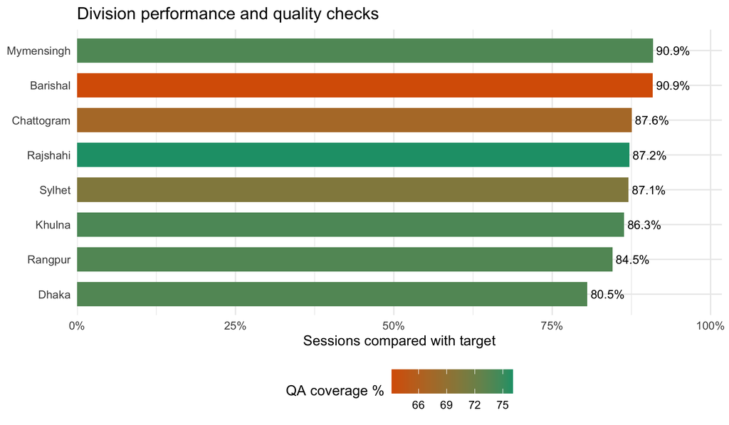

**Fig. 1: Division performance and quality assessment coverage.** The horizontal axis shows the session volume weighted **% Sessions vs Target**, while the vertical axis lists the eight divisions. Bar length and the printed percentage show the delivery result. However, The orange-to-green fill represents facility-weighted CCP QA coverage where orange indicates lower coverage and green indicates higher coverage. Bar length and color therefore show two separate indicators and should be interpreted together.

**Fig Interpretation**

While Mymensingh and Barishal has achieved similar targets however, the CCP QA assessment was relatively adequate in Mymensingh and comparatively lower in Barishal. This QA gap is evident clearly from the bi-variate chart color scale. Where the Bar size (length) indicates target achievement aspect and the color indicates the quality assessment aspect.

## Task A2 — Five-district source comparison

**Task A2:** Pick any 5 districts. For each, compare the district’s total sessions this quarter (`CCP_Monitoring_Data` file) against what you’d expect for a quarter based on that district’s facilities in `Average_sessions_details` file (their average monthly sessions × 3). Which districts, if any, look inconsistent between the two sources and for those, what’s your hypothesis for the gap? For the rest, do you expect the figures from the two sources to be similar, or would you want to verify the figures?

### Calculation method

For selected district (d), the monitoring total is:

$$Reported\ Sessions_d = \sum_{k \in \{ANC,PNC,SCANU,GM,GS,NCD\}}
Sessions_{d,k}$$

If facility (f) has historical average monthly sessions $\overline{M}_f$, the district’s expected quarterly sessions are:

$$Expected\ Sessions_d = 3 \times \sum_{f \in d}\overline{M}_f$$

The absolute and percentage gaps are:

$$Gap_d = Reported\ Sessions_d - Expected\ Sessions_d$$

$$Gap\ \%_d = \frac{Gap_d}{Expected\ Sessions_d} \times 100$$

I use $|Gap\ \%_d| > 20\%$ as a **review flag** where `d` indicates district, not a pass/fail standard, because the supplied files do not provide normal quarterly variation information or similar reporting period’s data.

### District selection and answer

**Table 8: Reported sessions compared with the three-month estimate**

| District | Monitoring sites | Older-file sites | This quarter | 3-month estimate | Difference | Interpretation |
| --- | --- | --- | --- | --- | --- | --- |
| Gopalganj | 8 | 6 | 95 | 74.7 | 27.2% | Current total is higher |
| Naogaon | 7 | 12 | 144 | 279.8 | -48.5% | Current total is lower |
| Rangamati | 11 | 13 | 184 | 179.2 | 2.7% | Totals are close |
| Habiganj | 10 | 10 | 227 | 163.0 | 39.3% | Current total is higher |
| Barguna | 21 | 9 | 311 | 216.9 | 43.4% | Current total is higher |

I chose one district from each fifth (ranked by the session-volume range) of the district per division, so the sample is not made up only of large or small districts. The estimate is the sum of each facility’s average monthly sessions multiplied by three from the historical data (facility level data) and calculated the current measure from the monitoring data. I used a 20% difference as a review flag (thumb rule), not as a pass mark, because the files do not provide normal month-to-month variation to consider a statistical standard deviation for the difference significance. On that basis, 4 of the five districts do not align. The remaining district has a similar session total but a different facility count, so all five need at least a quick check of reporting dates and active-facility lists before anyone treats the gaps as performance changes.

- **Gopalganj (Does not align):** Monitoring includes 2 more facilities, which probably explains part of the higher total session frequency. Need to check the active-facility list and start dates first.
- **Naogaon (Does not align):** Monitoring includes 5 fewer facilities, which probably explains part of the lower total session frequency. We should check inactive facilities and missing reports first.
- **Rangamati (Session totals are close):** The totals are close, but monitoring lists 11 facilities and the older file lists 13. The close result may be accidental, so need to check both facility lists and reporting dates.
- **Habiganj (Does not align):** Facility counts match, so the number of facilities does not explain the higher total session frequency. It is required to check whether activity grew, the periods differ, or the older average is no longer current.
- **Barguna (Does not align):** Monitoring includes 12 more facilities, which probably explains part of the higher total session frequency. Need to check the active-facility list and start dates first.

## Task A3 — Management priorities and dashboard

**Task A3:** Recommend the 3 divisions you would prioritize for management attention this quarter. State your indicators, it should combine more than one data dimension, and describe, in words, the dashboard you’d design for the Implementation Team using this kind of data. For each visual you propose, name the one decision or question it should help answer.

### Calculation method for the management-attention shortlist

I combined five dimensions: target achievement, QA coverage, sessions per facility, facilities per trainer, and program scale. However, one hurdle I faced was the different units of the available variables to combine into a attention index (named as priority score). For example, some variables have frequency scale and some have percentage scale. Therefore in order to combine them; I needed convert the measures in a equivalent scale. I used min-max Normalization formula, which transforms all the different values in unit-less scale (0 to 1). [Click Me](https://www.codecademy.com/article/min-max-zscore-normalization) to get more information of min-max normalization.

The calculation is as follows; for a any value ($x_i$), the min-max normalization is:

$$Normalized(x_i) = \frac{x_i - \min(x)}{\max(x) - \min(x)}$$

Now, my intention is to calculate metric (index) where Higher value means more risk/ requires greater attention and lower value indicates less risk/ requires lower attention. But the current variables which I plan to combine to make the index metric for attention, are not in the same direction. For example, `Weighted % Session vs Target` which is currently written as `Weighted Target %` for simplification (smaller variable name), indicates higher value indicates good (which should not need much attention) but in my metric indexing I need something where higher indicates `requires more attention`. Hence, I reversed the `Weighted Target %` by subtracting it from 100 (as it is a percent measure) and then normalized using the above function, to be used for calculating my attention index (named as priority score).

$$R_T = Normalized(100 - Weighted\ Target\ \%)$$

The same logic applies to `Weighter QA %`

$$R_Q = Normalized(100 - Weighted\ QA\ \%)$$

Now, for session per facility, the metric is in count; hence I reversed it by subtracting each value from the max value and then normalized using the initial min-max normalizing formula.

$$R_P = Normalized\!\left(\max(Sessions\ per\ Facility) - Sessions\ per\
Facility\right)$$

However, for facility per trainer and count of facility is in the same direction of my index. Because, higher number of facilities per trainer indicates higher risk and in general higher counts of facility infers higher possibilities of risk. hence I do not need to reverse these two indicators as these two metric by direction is already matches my attention index direction.

$$R_W = Normalized(Facilities\ per\ Trainer), \qquad
R_S = Normalized(Facilities)$$

Now, finally I created a formula where, I assigned some weights for each transformed variables to define its weight in the attention index (named as priority score) calculation. As I don’t have any recommendation from the project people and also do not have sufficient data to statistically define the weights, I am giving the weights to the individual variable from intuition. But I ensure that the sum of weights is 1, to ensure my index value ranges from 0 to 1.

The composite attention score is:

$$Priority\ Score = 100 \times
\left(0.30R_T + 0.30R_Q + 0.15R_P + 0.15R_W + 0.10R_S\right)$$
Where, These weights are a management assumption as stated above, not an official Noora Health standard.

$$0.30+ 0.30 + 0.15+ 0.15 + 0.10 = 1$$

### Answer

**Table 9: Three divisions that need the most attention**

| Division | Target % | QA % | Sessions/facility | Facilities/trainer | Priority score |
| --- | --- | --- | --- | --- | --- |
| Dhaka | 80.5 | 73.8 | 16.7 | 2.4 | 65.5 |
| Chattogram | 87.6 | 67.4 | 18.6 | 2.5 | 55.9 |
| Barishal | 90.9 | 63.1 | 23.9 | 3.1 | 48.3 |

**I used five practical signals:** missed targets (weight added = 30%), low QA coverage (weight added = 30%), fewer sessions per facility (weight added = 15%), more facilities per trainer (weights added = 15%), and the number of facilities affected (weights added = 10%). Please keep in mind that the table above also includes some calculated values to aid in assessing the priority score results. (not the reversed/ normalized variables). The reversed and normalized variables have only been used to calculate the priority scores.

**What I would do in the next 30 days**

- **Dhaka — why now:** Largest program (145 facilities), lowest target result (80.5%), and 16.7 sessions per facility. **First action:** Start with the lowest-target districts, Need to check session total against registers, and agree a six-week recovery plan with weekly follow-up.
- **Chattogram — why now:** Large program (128 facilities), 87.6% target result, and low QA coverage (67.4%). **First action:** Start QA follow-up in districts below 60% coverage and pair every check with coaching, an owner, and a due date.
- **Barishal — why now:** Lowest QA coverage (63.1%) and highest trainer load (3.1 facilities per trainer), despite strong session delivery. **First action:** Protect the strong session volume while increasing QA checks and rebalancing or clustering trainer support.

## Dashboard for the Implementation Team

**Interactive dashboard:** Open the one-page [Data Studio dashboard](https://datastudio.google.com/reporting/53dff60a-886b-4311-a038-4ae225fe3e6c)

The data studio dashboard above uses generated `DataStudio_Dashboard_Data.csv` from the given data, which contains 64 consolidated district rows. The four separate city reporting units are grouped with their parent districts in this dashboard dataset to prevent double-counting.

**Table 10: What each dashboard chart explains**

**note:** Please refer to the [dashboard](https://datastudio.google.com/reporting/53dff60a-886b-4311-a038-4ae225fe3e6c).

| Dashboard component | What it explains |
| --- | --- |
| Five scorecards | Summarize quarterly sessions, participants reached, weighted sessions versus target, weighted QA coverage, and the number of districts needing attention. |
| Division performance bars | Compare weighted delivery and QA results across divisions, showing whether each division’s main concern is session achievement, QA coverage, or both. |
| District bubble chart | Places sessions versus target on the X-axis and QA coverage on the Y-axis; bubble size represents quarterly sessions and color shows Urgent, Watch, or On track status. |
| Session-topic stacked bars | Show the share of ANC, PNC, SCANU, Medicine, Surgery, and NCD sessions in each division, making an unusual topic mix visible. |
| District exception table | Lists the districts requiring attention and shows the delivery, QA, workload, productivity, and cross-file indicators behind each flag. |

The division, district, and attention-status controls filter the page. The dataset is an undated current snapshot, so the dashboard does not claim to show a trend over time.

## Task A4 — Executive summary to the Country Director

**Task A4:** Write a 200–250 word executive summary of your findings addressed to the Country Director, who has 5 minutes to read it before a leadership meeting.

## Short Report to CD for decision making

Dear Country Director,

This quarter’s data differs across eight divisions. With session-volume weighting, Mymensingh ranks first and Dhaka ranks last (Figure 1). Mymensingh and Barishal are tied at 90.9%, so the small rank gap should not drive decisions. I recommend prioritizing Dhaka, Chattogram, Barishal. Dhaka has the lowest target achievement, largest facility network, and low sessions per facility. Chattogram has many facilities, below-target delivery, and low QA coverage. Barishal delivers sessions strongly, but has the lowest QA coverage and highest facilities-per-trainer load, which may explain its coverage gap (Table 9). The monitoring file contains 68 reporting areas. Combining four city areas with parent districts gives the expected 64 districts. Although both files total 658 facilities, 59 districts have different facility counts; this discrepancy requires a data-quality assessment. The brief states eight facility types, while the historical dataset contains nine. In the five-district review, Gopalganj, Naogaon, Habiganj, Barguna differ from the three-month estimate by over 20%. Rangamati’s totals are close, but its facility counts differ. These results may reflect different facility lists or reporting periods and should be verified before being treated as performance changes. Within 30 days, I would confirm active-facility lists and reporting dates, start Dhaka’s six-week recovery review, and address the largest QA gaps in Chattogram and Barishal. Following the collaborating, learning, and adapting (CLA) approach, I would work with the project team, share findings, and jointly develop practical tools through in-person discussions for example, a monthly dashboard with agreed owners and due dates for resolving identified issues.

*Word count: 250.*

# B. Monitoring the 15 remote expansion facilities

The expansion covers 15 new upazila hospitals in char and haor areas, located 4–6 hours one-way from the nearest divisional office, with unreliable mobile internet and trained nurses often transferring within 6–9 months.

## Task B1 — Monitoring approach, visits, risks, and mitigation

**Task B1:** Propose a monitoring approach for these 15 facilities given the connectivity and travel constraints described. Specify: (a) which 4–5 indicators you would prioritize tracking and why, (b) how data would be collected given intermittent connectivity, and (c) a realistic field-visit frequency, with your reasoning for why that frequency is achievable and sufficient. Identify the top 3 risks specific to this expansion and your mitigation approach for each.

### Answer: five priority indicators

I would propose five secondary indicators to be calculated from collecting relevant primary indicators from the field so it remains useful without creating excessive reporting burden for the front line workers.

**Table 11: Priority indicators for the 15 remote facilities**

**Note:** Each nominator and denominator variables in the following functions are the primary indicators to be collected from the field and the calculation functions are the secondary indicators.

| Indicator | Mathematical function | Why it matters |
| --- | --- | --- |
| Monthly session achievement | $\frac{Sessions\ delivered}{Sessions\ planned} \times 100$ | Shows whether CCP activity is happening at the expected pace. |
| Participant reach and mix | $Total\ participants = Patients + Caregivers$; $Participants/session = \frac{Patients + Caregivers}{Sessions}$ | Shows total reach, the two participant groups separately, and whether unusually high or low reach per session needs review. |
| Trained-nurse continuity | $\frac{Active\ trained\ nurses}{Planned\ trained\ posts} \times 100$, with main and backup named | Gives an early warning when a transfer could stop delivery. |
| Session-quality score | $\frac{Checklist\ items\ passed}{Checklist\ items\ assessed} \times 100$ | Checks whether sessions meet the agreed standard, not only whether they occurred. |
| Complete and timely reporting | $\frac{Complete\ reports\ received\ by\ due\ date}{Expected\ reports} \times 100$ | Separates a service-delivery problem from a reporting or connectivity problem. |

### Answer: offline-first data collection

The facility nurse should record activity in a register and also input the data in the offline form either in [kobo toolbox](https://support.kobotoolbox.org/data_collection_kobocollect.html) or [SurveyCTO’s documentation](https://docs.surveycto.com/01-getting-started/01-overview/06.collecting-data.html). These apps can collect offline and send data later when there is network available. So users can input the data in the app in offline mode and also document the same records in a register. Then within a defined period of time (e.g., once a week), the user must get connected to internet to upload the data.

### Answer: field-visit frequency and feasibility calculation

The monitoring officer should make an **initial visit within the first week of launch**, then visit each facility **once per quarter**. For an officer responsible for five facilities and ensure 1 visit per facility within each quarter, hence roughly 1-2 visits per month. This leaves time for remote checks, reporting review, weather delays, and urgent exceptions. Across all 15 facilities, the plan requires 15 routine visits per quarter by 3 officers, distributed among the responsible officers rather than assigned automatically to one person. Visits can be grouped only when routes and safety allow. During the monthly call, the facility contact should read aggregate totals from the paper register so the officer can compare them with the submitted data summary. If any discrepancy is identifies the data needs to be checked at individual entry level. Also, each physical visit should include a detailed record check and a live refresher training for enumerators. Quarterly direct verification is sufficient for routine oversight when monthly calls and warning rules identify problems earlier. One missed deadline should trigger a call; two missed reports, an unexplained zero, a major change, loss of trained staff, or a poor quality score should be considered for an earlier visit. This monthly review of completeness, timeliness, unusual changes, and source records follows the practical checks in the [WHO routine health facility data toolkit](https://www.who.int/data/data-collection-tools/health-service-data/toolkit-for-routine-health-information-system-data).

### Answer: three expansion-specific risks

**Table 12: Expansion-specific risks and mitigation actions**

| Expansion-specific risk | Mitigation |
| --- | --- |
| Trained nurses transfer after 6–9 months | Train a main and backup nurse at launch, require a short handover, and give replacements a remote orientation within two weeks. |
| Poor internet or an app failure causes missing or repeated records | Keep the paper register as the source, use an offline data submission application. |
| Weather and long travel delay support or create safety risks | Set quarterly routes with backup dates, use a local contact and check-in plan, avoid unsafe solo travel, and use warning signs to decide when an extra visit is required. |

## Task B2 — Managerial support for one monitoring officer

**Task B2:** One monitoring officer on your team will be responsible for covering 5 of these facilities largely on their own. What would you personally put in place, as their manager, to support them and protect data quality, without requiring them to travel more than is realistic? Answer in 4–6 sentences.

# C. Revised the draft monitoring plan

### Given draft plan in the assignment

> “We will track the number of sessions conducted and number of participants, self-reported monthly by each facility’s lead nurse via a WhatsApp message to the Program Managers (PMs). The Monitoring Team will compile this into a single master spreadsheet, shared with the research team who will also use it for their impact study. We will review the numbers once a quarter with the Implementation Team and flag any facility that reports zero sessions.”

## Task C1 — Weaknesses, risks, and rewritten plan

**Task C1:** Identify at least 3 specific weaknesses in this draft plan, and for each, explain the concrete risk it creates for Noora Health. Then rewrite the draft to fix it, in 3–5 sentences.

### Answer: specific weaknesses and concrete risks

**Table 13: Weaknesses in the draft monitoring plan and their risks**

| Weakness | Concrete risk |
| --- | --- |
| Only sessions and participants are tracked | High volume can hide poor session quality, missing topics, late reports, or the loss of trained staff. |
| Free-text WhatsApp messages have no fixed definitions, record ID, or receipt | Messages can be missed or repeated, and staff may count the same activity in different ways. |
| Program Managers receive the figures, but the plan does not name a separate person to check the data | Follow-up and data checking can become mixed together, and corrections may not be recorded consistently. |
| The live master spreadsheet is shared with the research team | Extra access, competing edits, and different definitions can create privacy, version, and consent problems. |
| Review happens only each quarter, and only zero sessions are flagged | Missing reports, low quality, sudden changes, and gradual decline may remain open for months. |

### Answer: Revised plan (4 sentences)

1. At each facility, I would keep a paper register as the source record and ask the nurse trained in data enumeration to submit a short SurveyCTO/ kobo toolbox form (with validation rules in place) by the fifth working day,
2. As these apps work offline, hence staff could enter data during connectivity gaps and sync it when a signal returns, while validation rules would flag missing fields, impossible values, sharp changes, and duplicate submissions.
3. I would use a Looker Studio dashboard linked to the approved dataset with api to track reporting status, sessions, reach, quality, staffing, and outstanding actions in near real time as submissions sync, with the Monitoring Team reviewing exceptions monthly and program managers doing the follow-ups.
4. Before sharing data with the team, the monitoring team will verify flagged throuugh DQA and keep record of every correction.

# D. Lessons from the field notes

### Eight notes supplied in the assignment

1. *“The flipchart images are a bit outdated; new mothers keep asking why the illustration shows a hospital bed different from ours. It’s a small thing, but it throws them off.”*
2. *“Three of our best-trained nurses at Jashore transferred in the last two months. The new ones need more supervision, but I don’t have the bandwidth to visit that often.”*
3. *“Mothers seem more engaged when the sessions happen right after their morning vitals check, rather than in the evening slot. Attendance drops noticeably in the evening sessions.”*
4. *“I had to fill out the SurveyCTO form twice this week because the app crashed halfway through and didn’t save anything. I’ve started keeping a paper backup now.”*
5. *“During Ramadan, session timing needs to shift; we had almost no attendance in the 1 pm slot for two weeks straight.”*
6. *“One of the fathers waiting outside asked if he could join the session; we said no because it’s meant for mothers and female caregivers, but he seemed really eager to learn.”*
7. *“The PM visited last month and reviewed our numbers but didn’t ask us about the connectivity issues we’ve been having; we’ve mentioned it three times now in our monthly calls.”*
8. *“A caregiver told us she’d already learned the same information from a poster in the hallway, so she left the session early. We might be duplicating some content.”*

## Task D1 — Thematic synthesis

**Task D1:** Group the 8 notes above into 3–4 themes of your own choosing. For each theme: give it a short label, write one sentence on the underlying pattern it points to—not a summary of the quotes, but what it tells us about the program—and say whether you’d treat it as an isolated incident or something to escalate as systemic, with your reasoning.

### Answer

**Table 14: Themes derived from the eight qualitative notes**

**Note:** I am grouping them under four themes.

[output not shown]

## Task D2 — Program Learning Note and systematic feedback process

**Task D2:** Draft a 100–150 word Program Learning Note, to share qualitative insight with the design and implementation teams based on your synthesis above. Propose one concrete process or tool change you’d recommend so this kind of feedback gets captured more systematically going forward.

### Answer: Program Learning Note

Recent field feedback shows design and support gaps reducing session quality. Materials become outdated when improvements are infrequent, and some repeat information families already received. Attendance varies with ward routines and Ramadan, while participation rules can exclude interested family members. Nurse transfers leave replacement staff needing support. Staff also report app data loss and uncertainty about whether issues raised during calls are acted upon. I recommend periodic data training, an offline submission tool with validation rules, and a matching paper register as a backup and audit reference. Unexpected issues should be entered in both an event register and a digital feedback-and-action log that alerts management; emergencies should also be escalated by direct call. The log should capture facility, theme, urgency, owner, due date, status, and closure. Monitoring and Implementation teams should review it monthly, resolve issues, and return documented feedback to each person who raised one.

*Word count: 146.*

**Concrete process/tool change:** Add one offline feedback-and-action log to the monthly monitoring form, with mandatory fields for facility, theme, urgency, owner, due date, status, and closure note; review it jointly each month and return the documented resolution to the person who raised the issue.

# Exported data workbook

The cleaned source data, comparison tables, results, and data checks are saved in `Updated_Data.xlsx`.

# What the data cannot tell us

- The files do not say which quarter was reported or the exact period behind the older averages. The quarter estimates are only a rough comparison, not a prediction.
- Because there is only one undated snapshot, the files cannot show improvement or decline over time. A real trend requires repeated rows with a valid reporting-period date.
- Most district facility counts differ between the two files. I could not settle these differences because the files do not share a fixed facility ID or dated facility list.
- City rows were grouped with their parent districts only when comparing the two files. The original monitoring locations were kept.
- The dashboard red/amber/green thresholds are demonstration assumptions, not confirmed organizational policy.
- The files do not include geographic codes or coordinates, so a district map may misclassify locations and is not recommended yet.
- I kept the rounded averages from the source files. Session and participant totals were added again from the detailed columns so the maths could be checked.
- Every cleaning step and calculation is in this R Markdown file. No cleaned value was changed by hand outside the code.

# References used for the practical recommendations

- GeeksforGeeks. [Weighted Average Formula](https://www.geeksforgeeks.org/maths/weighted-average-formula/).
- Codecademy. [Normalization: Min-Max and Z-Score](https://www.codecademy.com/article/min-max-zscore-normalization).
- Google Data Studio. [Monitoring dashboard](https://datastudio.google.com/reporting/53dff60a-886b-4311-a038-4ae225fe3e6c).
- KoboToolbox. [Collecting data with KoboCollect](https://support.kobotoolbox.org/data_collection_kobocollect.html).
- World Health Organization. [Toolkit for Routine Health Information Systems data](https://www.who.int/data/data-collection-tools/health-service-data/toolkit-for-routine-health-information-system-data).
- SurveyCTO. [Collecting data online and offline](https://docs.surveycto.com/01-getting-started/01-overview/06.collecting-data.html).
- Google Cloud. [Connect to Google Sheets in Data Studio (Previously Looker Studio)](https://cloud.google.com/looker/docs/studio/connect-to-google-sheets).

# Abbreviations

- ANC = Antenatal Care
- CCP = Care Companion Program
- NCD = Non-Communicable Disease
- PNC = Postnatal Care
- QA = Quality Assessment
- SCANU = Special Care Newborn Unit